# Principal Component Analysis (Case Study)

## A PCA Case Study

- This presentation is designed to serve as an example of how you might use PCA
- The data come from a chemical analysis of wines grown in the same region of Italy
  - 13 characteristics are measured, though we suspect many of them are related
  - Further, it is known that 3 different cultivars provided these wine samples, so we are interested in seeing if the practices of these cultivars lead to noticeably different chemical profiles

```r
head(wine)
```

```
##   Alcohol MalicAcid  Ash Alkalinity  Mg TotalPhenols Flavanoids
## 1   14.23      1.71 2.43       15.6 127         2.80       3.06
## 2   13.20      1.78 2.14       11.2 100         2.65       2.76
## 3   13.16      2.36 2.67       18.6 101         2.80       3.24
## 4   14.37      1.95 2.50       16.8 113         3.85       3.49
## 5   13.24      2.59 2.87       21.0 118         2.80       2.69
## 6   14.20      1.76 2.45       15.2 112         3.27       3.39
##   NonFlavanoidPhenols Proanthocyanins ColorIntensity  Hue OD280-OD315Ratio
## 1                0.28            2.29           5.64 1.04             3.92
## 2                0.26            1.28           4.38 1.05             3.40
## 3                0.30            2.81           5.68 1.03             3.17
## 4                0.24            2.18           7.80 0.86             3.45
## 5                0.39            1.82           4.32 1.04             2.93
## 6                0.34            1.97           6.75 1.05             2.85
##   Proline
## 1    1065
## 2    1050
## 3    1185
## 4    1480
## 5     735
## 6    1450
```

## Exploratory Data Analysis

- Upon first seeing any dataset it is rare that you’ll immediately know the analysis strategy to use
- **Exploratory data analysis** (EDA) is an important part of data science
- The very first thing you should do is to use the `summary` function to get descriptive statistics on the variables you’ll be working with:

```r
summary(wine)
```

```
##     Alcohol        MalicAcid          Ash          Alkalinity
##  Min.   :11.03   Min.   :0.740   Min.   :1.360   Min.   :10.60
##  1st Qu.:12.36   1st Qu.:1.603   1st Qu.:2.210   1st Qu.:17.20
##  Median :13.05   Median :1.865   Median :2.360   Median :19.50
##  Mean   :13.00   Mean   :2.336   Mean   :2.367   Mean   :19.49
##  3rd Qu.:13.68   3rd Qu.:3.083   3rd Qu.:2.558   3rd Qu.:21.50
##  Max.   :14.83   Max.   :5.800   Max.   :3.230   Max.   :30.00
##        Mg          TotalPhenols     Flavanoids    NonFlavanoidPhenols
##  Min.   : 70.00   Min.   :0.980   Min.   :0.340   Min.   :0.1300
##  1st Qu.: 88.00   1st Qu.:1.742   1st Qu.:1.205   1st Qu.:0.2700
##  Median : 98.00   Median :2.355   Median :2.135   Median :0.3400
##  Mean   : 99.74   Mean   :2.295   Mean   :2.029   Mean   :0.3619
##  3rd Qu.:107.00   3rd Qu.:2.800   3rd Qu.:2.875   3rd Qu.:0.4375
##  Max.   :162.00   Max.   :3.880   Max.   :5.080   Max.   :0.6600
##  Proanthocyanins ColorIntensity        Hue         OD280-OD315Ratio
##  Min.   :0.410   Min.   : 1.280   Min.   :0.4800   Min.   :1.270
##  1st Qu.:1.250   1st Qu.: 3.220   1st Qu.:0.7825   1st Qu.:1.938
##  Median :1.555   Median : 4.690   Median :0.9650   Median :2.780
##  Mean   :1.591   Mean   : 5.058   Mean   :0.9574   Mean   :2.612
##  3rd Qu.:1.950   3rd Qu.: 6.200   3rd Qu.:1.1200   3rd Qu.:3.170
##  Max.   :3.580   Max.   :13.000   Max.   :1.7100   Max.   :4.000
##     Proline
##  Min.   : 278.0
##  1st Qu.: 500.5
##  Median : 673.5
##  Mean   : 746.9
##  3rd Qu.: 985.0
##  Max.   :1680.0
```

- Notice that most of these variables seem pretty well-behaved, though `MalicAcid` and `Proline` are somewhat right-skewed and could be candidates for log-transformations

## Exploratory Data Analysis

- Because we’re interested in how variables are related, a **scatterplot matrix** is a useful next step in our EDA
- `R` will construct this plot using the `pairs` function:

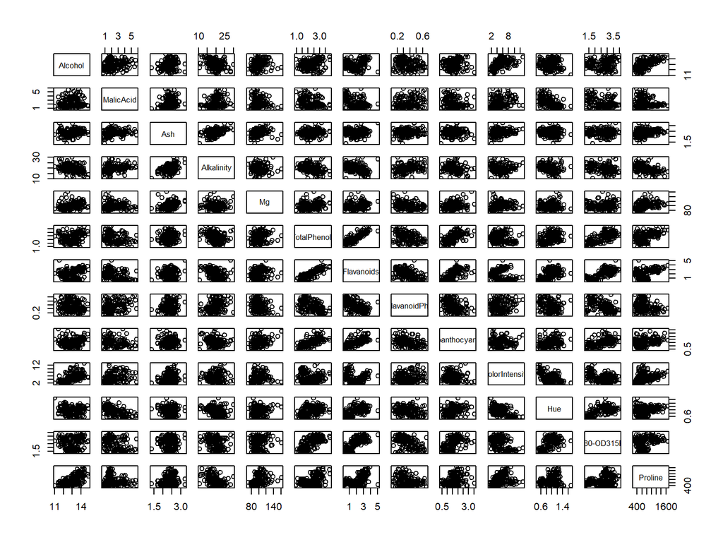

```r
pairs(wine)
```

- Notice how this graphic presents *way* too much information; however, we can clearly see that several variables appear related
- The complexity of the scatterplot matrix leads us to consider PCA as a tool for understanding the multivariate nature of these data
  - Had this plot been easier to digest we might not want to use PCA

## Principal Component Analysis

- Recall that the `prcomp` function is used to perform PCA, and before using it we should standardize our data:

```r
wine_std <- scale(wine)
P <- prcomp(wine_std)
P
```

```
## Standard deviations (1, .., p=13):
##  [1] 2.1692972 1.5801816 1.2025273 0.9586313 0.9237035 0.8010350 0.7423128
##  [8] 0.5903367 0.5374755 0.5009017 0.4751722 0.4108165 0.3215244
##
## Rotation (n x k) = (13 x 13):
##                              PC1          PC2         PC3         PC4
## Alcohol             -0.144329395  0.483651548 -0.20738262  0.01785630
## MalicAcid            0.245187580  0.224930935  0.08901289 -0.53689028
## Ash                  0.002051061  0.316068814  0.62622390  0.21417556
## Alkalinity           0.239320405 -0.010590502  0.61208035 -0.06085941
## Mg                  -0.141992042  0.299634003  0.13075693  0.35179658
## TotalPhenols        -0.394660845  0.065039512  0.14617896 -0.19806835
## Flavanoids          -0.422934297 -0.003359812  0.15068190 -0.15229479
## NonFlavanoidPhenols  0.298533103  0.028779488  0.17036816  0.20330102
## Proanthocyanins     -0.313429488  0.039301722  0.14945431 -0.39905653
## ColorIntensity       0.088616705  0.529995672 -0.13730621 -0.06592568
## Hue                 -0.296714564 -0.279235148  0.08522192  0.42777141
## OD280-OD315Ratio    -0.376167411 -0.164496193  0.16600459 -0.18412074
## Proline             -0.286752227  0.364902832 -0.12674592  0.23207086
##                             PC5         PC6         PC7         PC8
## Alcohol             -0.26566365  0.21353865 -0.05639636  0.39613926
## MalicAcid            0.03521363  0.53681385  0.42052391  0.06582674
## Ash                 -0.14302547  0.15447466 -0.14917061 -0.17026002
## Alkalinity           0.06610294 -0.10082451 -0.28696914  0.42797018
## Mg                   0.72704851  0.03814394  0.32288330 -0.15636143
## TotalPhenols        -0.14931841 -0.08412230 -0.02792498 -0.40593409
## Flavanoids          -0.10902584 -0.01892002 -0.06068521 -0.18724536
## NonFlavanoidPhenols -0.50070298 -0.25859401  0.59544729 -0.23328465
## Proanthocyanins      0.13685982 -0.53379539  0.37213935  0.36822675
## ColorIntensity      -0.07643678 -0.41864414 -0.22771214 -0.03379692
## Hue                 -0.17361452  0.10598274  0.23207564  0.43662362
## OD280-OD315Ratio    -0.10116099  0.26585107 -0.04476370 -0.07810789
## Proline             -0.15786880  0.11972557  0.07680450  0.12002267
##                             PC9        PC10        PC11        PC12
## Alcohol             -0.50861912  0.21160473  0.22591696 -0.26628645
## MalicAcid            0.07528304 -0.30907994 -0.07648554  0.12169604
## Ash                  0.30769445 -0.02712539  0.49869142 -0.04962237
## Alkalinity          -0.20044931  0.05279942 -0.47931378 -0.05574287
## Mg                  -0.27140257  0.06787022 -0.07128891  0.06222011
## TotalPhenols        -0.28603452 -0.32013135 -0.30434119 -0.30388245
## Flavanoids          -0.04957849 -0.16315051  0.02569409 -0.04289883
## NonFlavanoidPhenols -0.19550132  0.21553507 -0.11689586  0.04235219
## Proanthocyanins      0.20914487  0.13418390  0.23736257 -0.09555303
## ColorIntensity      -0.05621752 -0.29077518 -0.03183880  0.60422163
## Hue                 -0.08582839 -0.52239889  0.04821201  0.25921400
## OD280-OD315Ratio    -0.13722690  0.52370587 -0.04642330  0.60095872
## Proline              0.57578611  0.16211600 -0.53926983 -0.07940162
##                            PC13
## Alcohol              0.01496997
## MalicAcid            0.02596375
## Ash                 -0.14121803
## Alkalinity           0.09168285
## Mg                   0.05677422
## TotalPhenols        -0.46390791
## Flavanoids           0.83225706
## NonFlavanoidPhenols  0.11403985
## Proanthocyanins     -0.11691707
## ColorIntensity      -0.01199280
## Hue                 -0.08988884
## OD280-OD315Ratio    -0.15671813
## Proline              0.01444734
```

- The PCA output is intimidating to jump straight into, so let’s visualize the results instead

## Principal Component Analysis

- To begin, we’ll try to understand the first two principal components using a **biplot**, a type of plot that depicts the scores of data-points, and the loadings of the original variables, in any two of the principal component dimensions.

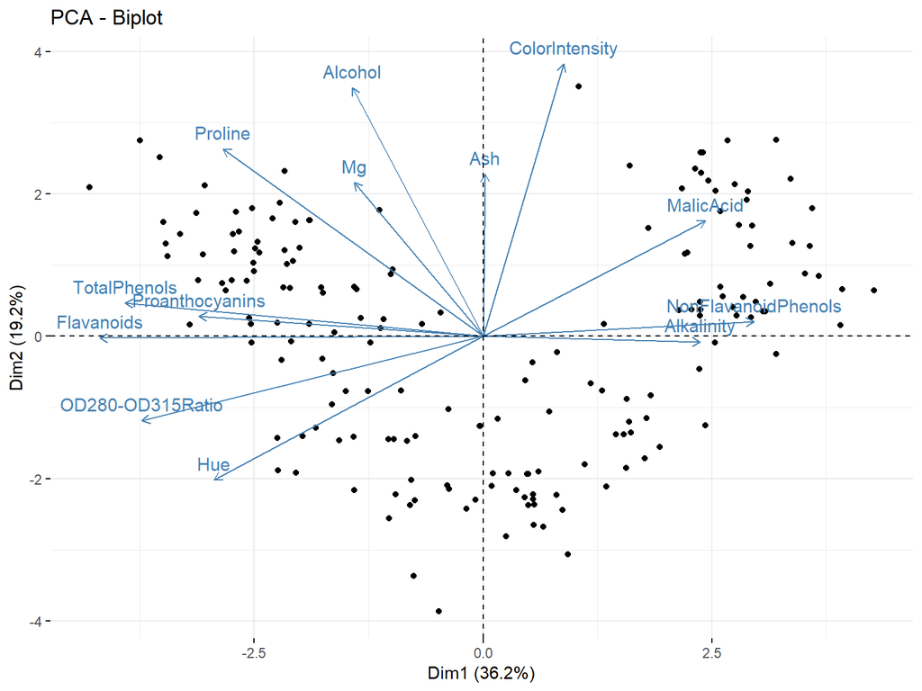

## Choosing the Number of Components

- In most PCA applications the first two principal components will almost always be of interest
  - How many principal components to consider beyond the first two is an important question
- The most common way to make this decision is by looking at the *proportion of variance explained*
  - Like any variable, the scores in each principal component have variation
  - If the scores in a principal component dimension have a lot of variation, it implies that component is useful in separating the data (ie: there is a lot of unique information contained in that dimension)
  - If the scores do not have a lot of variation, it implies that component isn’t very interesting

## Screeplots

- A **screeplot** is a visual representation of the variance explained by each principal component

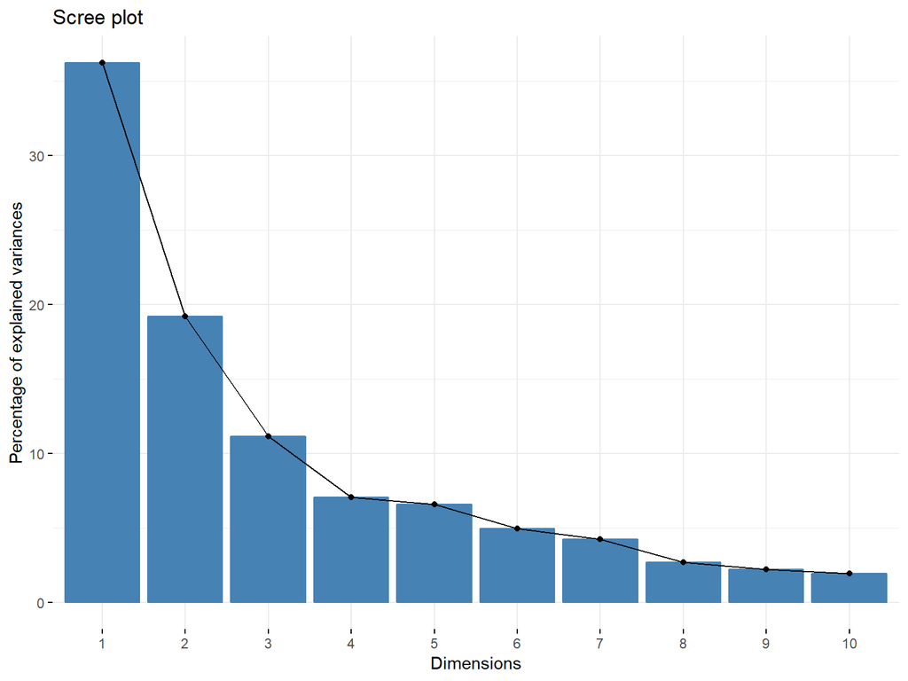

- Here we see that 55% of the variation in the data exists in just two dimensions (PC1 and PC2)
- 66% of the variation exists in three dimensions (PC1, PC2, and PC3)
- These percentages might seem low, but they are actually quite good considering the original data had 13 dimensions!
- Many methods have been proposed for selecting a suitable number of components (see: https://biologydirect.biomedcentral.com/articles/10.1186/1745-6150-2-2) though there isn’t much consensus, so we’ll simply inspect the screeplot
- Based upon the screeplot, it seems that using 2 or 3 principal components will provide an effective dimension reduction

## Results

- When introducing these data I mentioned the samples originated from 3 different cultivars in the same region
  - The first 2 principal components can clearly distinguish those cultivars
- In contrast, no combination of the original variables provides such a clear two-dimensional representation

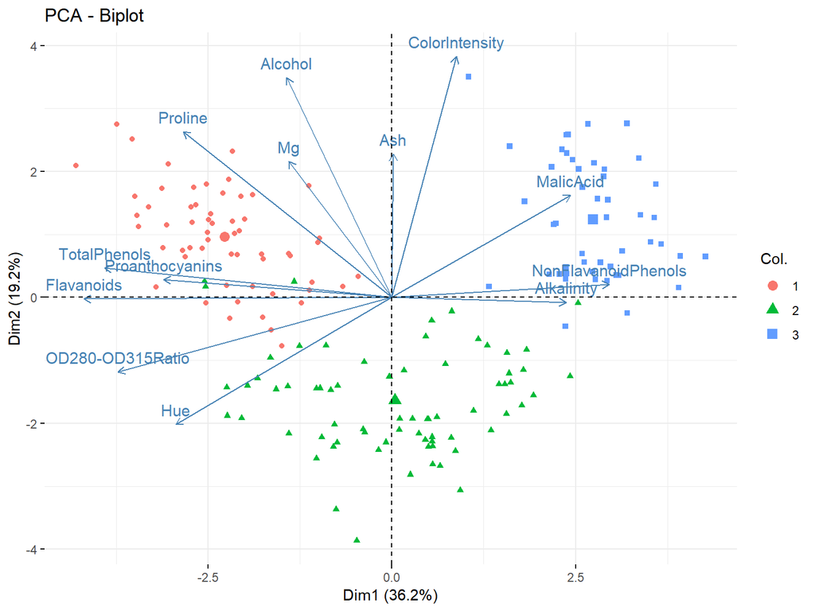

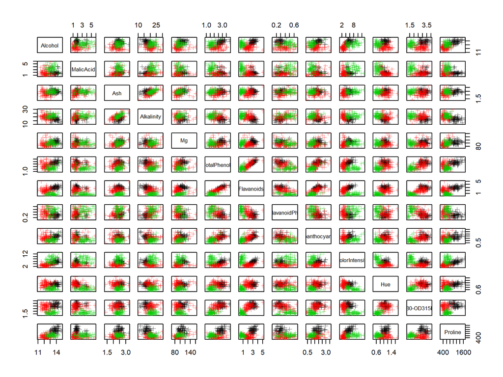

## Next Steps

- We’ll see later on that PCA has uses in **clustering** and **supervised learning**
- For now, you should view PCA as a tool used to find and describe multivariate relationships in data containing more variables than you can comfortably display in a single graphic